# Akula-DATA606-Lab0

Pavan Akula

February 3, 2017

Following command loads data from present.R located in working directory/more folder and also creates data frame.

```r
source("more/present.R")
```

```r
source("more/arbuthnot.R")
```

```r
present
```

```
##    year    boys   girls
## 1  1940 1211684 1148715
## 2  1941 1289734 1223693
## 3  1942 1444365 1364631
## 4  1943 1508959 1427901
## 5  1944 1435301 1359499
## 6  1945 1404587 1330869
## 7  1946 1691220 1597452
## 8  1947 1899876 1800064
## 9  1948 1813852 1721216
## 10 1949 1826352 1733177
## 11 1950 1823555 1730594
## 12 1951 1923020 1827830
## 13 1952 1971262 1875724
## 14 1953 2001798 1900322
```

[output cut: 49 more lines]

Q 1: What years are included in this data set? What are the dimensions of the data frame and what are the variable or column names?

A: Total of 63 years from 1940 to 2002.

```r
present$year
```

```
##  [1] 1940 1941 1942 1943 1944 1945 1946 1947 1948 1949 1950 1951 1952 1953
## [15] 1954 1955 1956 1957 1958 1959 1960 1961 1962 1963 1964 1965 1966 1967
## [29] 1968 1969 1970 1971 1972 1973 1974 1975 1976 1977 1978 1979 1980 1981
## [43] 1982 1983 1984 1985 1986 1987 1988 1989 1990 1991 1992 1993 1994 1995
## [57] 1996 1997 1998 1999 2000 2001 2002
```

Dimensions of the data frame present are

```r
dim(present)
```

```
## [1] 63  3
```

Columns in the data frame are

```r
names(present)
```

```
## [1] "year"  "boys"  "girls"
```

Q 2:How do these counts compare to Arbuthnot’s? Are they on a similar scale?

A: Present data frame counts are much higher than Arbuthnot counts and also they belong to different period of time. Present data frame years range from 1940 to 2002 on the other hand Arbuthnot data frame years range from 1629 - 1710. I believe they are similar scale because

1. Both data frames have 3 columns
2. Both data frame have year column as categorical variable and boys and girls as numerical variables.

```r
dim(arbuthnot)
```

```
## [1] 82  3
```

Q 3: Make a plot that displays the boy-to-girl ratio for every year in the data set. What do you see? Does Arbuthnot’s observation about boys being born in greater proportion than girls hold up in the U.S.? Include the plot in your response.

A: Following command is used to calculate boy-to-girl ratio. Command will add extra column “boyTogirlratio” to data frame present.

```r
present$boyTogirlratio <- present$boys / present$girls
```

```r
present$boyTogirlratio
```

```
##  [1] 1.054817 1.053969 1.058429 1.056767 1.055757 1.055391 1.058698
##  [8] 1.055449 1.053820 1.053760 1.053716 1.052078 1.050934 1.053399
## [15] 1.051460 1.050742 1.051286 1.050672 1.049374 1.049480 1.048873
## [22] 1.050057 1.047948 1.052717 1.047188 1.051137 1.048540 1.049964
## [29] 1.053417 1.052997 1.054719 1.051845 1.051271 1.052129 1.054797
## [36] 1.053605 1.052538 1.052569 1.052657 1.051749 1.052837 1.051615
## [43] 1.050597 1.051976 1.050199 1.052061 1.050876 1.050000 1.049991
## [50] 1.049720 1.049676 1.045849 1.050017 1.049955 1.047877 1.048928
## [57] 1.047062 1.047643 1.047190 1.048791 1.047998 1.045686 1.047986
```

```r
subset(present, select=c(year, boyTogirlratio))
```

```
##    year boyTogirlratio
## 1  1940       1.054817
## 2  1941       1.053969
## 3  1942       1.058429
## 4  1943       1.056767
## 5  1944       1.055757
## 6  1945       1.055391
## 7  1946       1.058698
## 8  1947       1.055449
## 9  1948       1.053820
## 10 1949       1.053760
## 11 1950       1.053716
## 12 1951       1.052078
## 13 1952       1.050934
## 14 1953       1.053399
```

[output cut: 49 more lines]

As the years progressed ratio was getting reduced. In the year 1946, there were more boys born compared to girls. After 1946 difference started reducing. Yes, Arbuthnot’s observation about boys being born in greater proportion than girls holds good in the U.S. too. Following is the plot displaying years and boy-to-girl ratio.

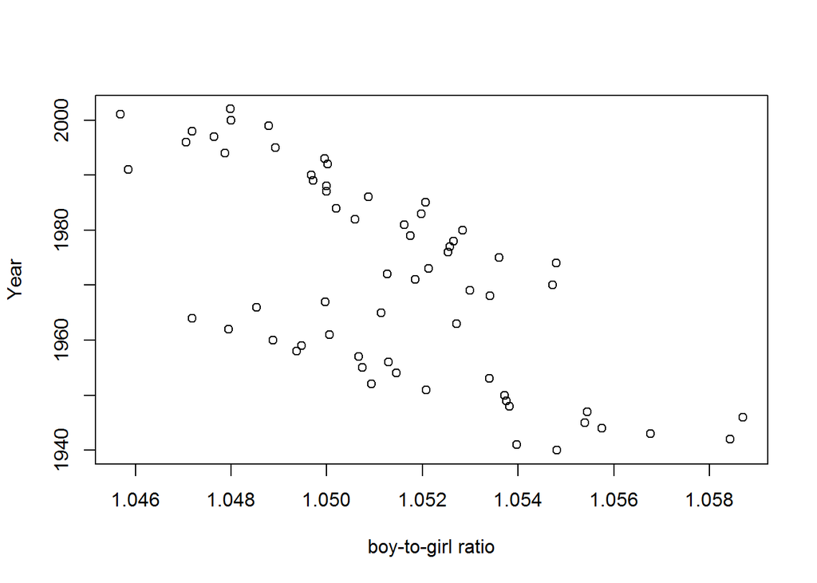

```r
plot(y=present$year, x=present$boyTogirlratio,ylab="Year",xlab="boy-to-girl ratio")
```

Q 4: In what year did we see the most total number of births in the U.S.?

A: Most births happened in year 1961, total of 4268326.

```r
present$totalbirth <- present$boys + present$girls
```

```r
present[present$totalbirth == max(present$totalbirth),]
```

```
##    year    boys   girls boyTogirlratio totalbirth
## 22 1961 2186274 2082052       1.050057    4268326
```